# Ley de los Grandes Números y Teorema del Límite Central

**Curso:** Modelado Bajo Incertidumbre  
**Universidad de los Andes — Ingeniería Industrial**

## Motivación

Dos de los resultados más fundamentales de la teoría de probabilidades son:

- **Ley de los Grandes Números (LGN):** Justifica por qué los promedios muestrales convergen al valor esperado poblacional.
- **Teorema del Límite Central (TLC):** Explica por qué tantos fenómenos naturales siguen una distribución aproximadamente normal.

## Objetivos de aprendizaje

Al finalizar este notebook deberías poder:

1. Enunciar formalmente la **Ley de los Grandes Números** (débil y fuerte)
2. Entender la diferencia entre **convergencia en probabilidad** y **casi segura**
3. Enunciar e interpretar el **Teorema del Límite Central**
4. Visualizar la convergencia de la media muestral
5. Observar cómo la distribución de sumas se vuelve normal
6. Aplicar estos conceptos a problemas prácticos de ingeniería
7. Construir **intervalos de confianza** asintóticos

```python
import numpy as np
import matplotlib.pyplot as plt
from matplotlib.patches import FancyBboxPatch
import scipy.stats as stats
from ipywidgets import interact, IntSlider, FloatSlider, Dropdown
import warnings
warnings.filterwarnings('ignore')

# Estilo de gráficos
plt.style.use('seaborn-v0_8-darkgrid')
plt.rcParams['figure.figsize'] = (12, 6)
plt.rcParams['font.size'] = 11
plt.rcParams['axes.titlesize'] = 14
plt.rcParams['axes.labelsize'] = 12

# Generador reproducible
SEED = 42
rng = np.random.default_rng(SEED)

# Paleta de colores personalizada
COLORS = {
    'primary': '#1E3A5F',      # Azul oscuro elegante
    'secondary': '#D64045',    # Rojo coral
    'accent': '#3891A6',       # Azul turquesa
    'highlight': '#E8B341',    # Dorado
    'success': '#4A7C59',      # Verde bosque
    'neutral': '#545454',      # Gris
    'light': '#F0E6D2'         # Beige claro
}

print("✅ Librerías cargadas correctamente")
```

```
✅ Librerías cargadas correctamente
```

# Parte I: Ley de los Grandes Números (LGN)

## 1. Definición Formal

### 1.1 Configuración

Sea $\{X_i\}_{i=1}^{n}$ una secuencia de variables aleatorias **i.i.d.** (independientes e idénticamente distribuidas) con:

$$\mathbb{E}[X_i] = \mu \quad \text{y} \quad \text{Var}(X_i) = \sigma^2 < \infty$$

Definimos la **media muestral** como:

$$\bar{X}_n = \frac{1}{n}\sum_{i=1}^{n} X_i$$

### 1.2 Ley Débil de los Grandes Números (LDGN)

La media muestral converge **en probabilidad** a la media poblacional:

$$\bar{X}_n \xrightarrow{P} \mu \quad \text{cuando } n \to \infty$$

Formalmente: para todo $\varepsilon > 0$,

$$\lim_{n \to \infty} \mathbb{P}\left(|\bar{X}_n - \mu| > \varepsilon\right) = 0$$

### 1.3 Ley Fuerte de los Grandes Números (LFGN)

La media muestral converge **casi seguramente** a la media poblacional:

$$\bar{X}_n \xrightarrow{\text{a.s.}} \mu \quad \text{cuando } n \to \infty$$

Formalmente:

$$\mathbb{P}\left(\lim_{n \to \infty} \bar{X}_n = \mu\right) = 1$$

### 1.4 Interpretación intuitiva

> **"Si repetimos un experimento muchas veces, el promedio observado se estabiliza cerca del valor esperado teórico."**

Esto justifica:

- Usar frecuencias relativas para estimar probabilidades
- Promediar múltiples mediciones para reducir error
- La simulación Monte Carlo como método de estimación

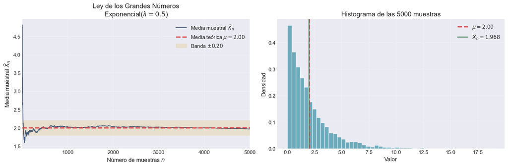

```
📊 Resumen para Exponencial($\lambda=0.5$):
   Media teórica μ = 2.0000
   Media muestral X̄ₙ = 1.9675
   Error absoluto |X̄ₙ - μ| = 0.032479
```

```python
# EJEMPLO 1: Visualización de la LGN con diferentes distribuciones

def demostrar_lgn(distribucion='Exponencial', n_max=5000, seed=42):
    """
    Demuestra la Ley de los Grandes Números para diferentes distribuciones.
    """
    rng_local = np.random.default_rng(seed)

    # Configurar distribución
    if distribucion == 'Exponencial':
        lam = 0.5
        X = rng_local.exponential(scale=1/lam, size=n_max)
        mu_real = 1/lam
        titulo_dist = f'Exponencial($\\lambda={lam}$)'
    elif distribucion == 'Uniforme':
        a, b = 0, 10
        X = rng_local.uniform(a, b, size=n_max)
        mu_real = (a + b) / 2
        titulo_dist = f'Uniforme({a}, {b})'
    elif distribucion == 'Bernoulli':
        p = 0.3
        X = rng_local.binomial(1, p, size=n_max)
        mu_real = p
        titulo_dist = f'Bernoulli(p={p})'
    elif distribucion == 'Poisson':
        lam = 4
        X = rng_local.poisson(lam, size=n_max)
        mu_real = lam
        titulo_dist = f'Poisson($\\lambda={lam}$)'
    else:  # Normal
        mu, sigma = 5, 2
        X = rng_local.normal(mu, sigma, size=n_max)
        mu_real = mu
        titulo_dist = f'Normal($\\mu={mu}, \\sigma={sigma}$)'

    # Calcular media acumulada
    n_vals = np.arange(1, n_max + 1)
    media_acumulada = np.cumsum(X) / n_vals

    # Crear figura
    fig, axes = plt.subplots(1, 2, figsize=(15, 5))

    # Panel izquierdo: Convergencia de la media
    ax1 = axes[0]
    ax1.plot(n_vals, media_acumulada, color=COLORS['primary'], linewidth=1.5, alpha=0.8, label='Media muestral $\\bar{X}_n$')
    ax1.axhline(mu_real, color=COLORS['secondary'], linestyle='--', linewidth=2.5, label=f'Media teórica $\\mu = {mu_real:.2f}$')

    # Bandas de tolerancia
    epsilon = 0.1 * mu_real if mu_real != 0 else 0.1
    ax1.fill_between(n_vals, mu_real - epsilon, mu_real + epsilon,
                     color=COLORS['highlight'], alpha=0.2, label=f'Banda $\\pm {epsilon:.2f}$')

    ax1.set_xlabel('Número de muestras $n$')
    ax1.set_ylabel('Media muestral $\\bar{X}_n$')
    ax1.set_title(f'Ley de los Grandes Números\n{titulo_dist}')
    ax1.legend(loc='upper right')
    ax1.set_xlim([1, n_max])
    ax1.grid(True, alpha=0.3)

    # Panel derecho: Distribución original
    ax2 = axes[1]
    ax2.hist(X, bins=50, density=True, color=COLORS['accent'], alpha=0.7, edgecolor='white')
    ax2.axvline(mu_real, color=COLORS['secondary'], linestyle='--', linewidth=2.5, label=f'$\\mu = {mu_real:.2f}$')
    ax2.axvline(np.mean(X), color=COLORS['success'], linestyle='-', linewidth=2, label=f'$\\bar{{X}}_n = {np.mean(X):.3f}$')
    ax2.set_xlabel('Valor')
    ax2.set_ylabel('Densidad')
    ax2.set_title(f'Histograma de las {n_max} muestras')
    ax2.legend()
    ax2.grid(True, alpha=0.3)

    plt.tight_layout()
    plt.show()

    # Resumen
    error_final = abs(media_acumulada[-1] - mu_real)
    print(f"\n📊 Resumen para {titulo_dist}:")
    print(f"   Media teórica μ = {mu_real:.4f}")
    print(f"   Media muestral X̄ₙ = {media_acumulada[-1]:.4f}")
    print(f"   Error absoluto |X̄ₙ - μ| = {error_final:.6f}")

# Demostración con distribución exponencial
demostrar_lgn('Exponencial', n_max=5000)
```

```python
# 🎛️ GRÁFICO INTERACTIVO: LGN con selector de distribución

@interact(
    distribucion=Dropdown(
        options=['Exponencial', 'Uniforme', 'Bernoulli', 'Poisson', 'Normal'],
        value='Exponencial',
        description='Distribución:'
    ),
    n_max=IntSlider(min=100, max=10000, step=100, value=2000, description='n máximo:'),
    seed=IntSlider(min=1, max=100, value=42, description='Semilla:')
)
def lgn_interactivo(distribucion, n_max, seed):
    demostrar_lgn(distribucion, n_max, seed)
```

```
interactive(children=(Dropdown(description='Distribución:', options=('Exponencial', 'Uniforme', 'Bernoulli', '…
```

## 2. Tasa de Convergencia y la Desigualdad de Chebyshev

### 2.1 ¿Qué tan rápido converge la media muestral?

La varianza de la media muestral es:

$$\text{Var}(\bar{X}_n) = \frac{\sigma^2}{n}$$

Por lo tanto, el **error estándar** es:

$$\text{SE}(\bar{X}_n) = \frac{\sigma}{\sqrt{n}}$$

### 2.2 Desigualdad de Chebyshev

Para cualquier $\varepsilon > 0$:

$$\mathbb{P}\left(|\bar{X}_n - \mu| \geq \varepsilon\right) \leq \frac{\sigma^2}{n\varepsilon^2}$$

Esta desigualdad **no asume** ninguna forma específica de la distribución.

### 2.3 Implicación práctica

| Factor de mejora en precisión | Muestras necesarias |
| --- | --- |
| 2× | 4n |
| 10× | 100n |
| k× | k²n |

> **Regla del $\sqrt{n}$:** Para duplicar la precisión, necesitamos cuadruplicar el tamaño de muestra.

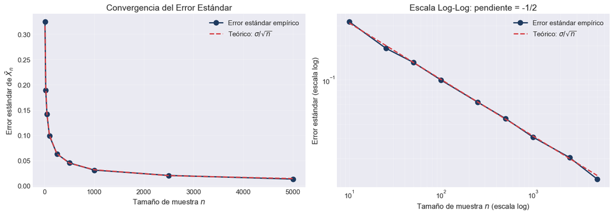

```
📐 Verificación de la regla del √n:
   n=100:  SE teórico = 0.1000
   n=400:  SE teórico = 0.0500  (mitad del anterior)
   n=10000: SE teórico = 0.0100 (1/10 del de n=100)
```

```python
# EJEMPLO 2: Visualización de la tasa de convergencia O(1/√n)

def visualizar_tasa_convergencia(n_repeticiones=500, seed=42):
    """
    Visualiza cómo el error estándar decrece con O(1/√n).
    """
    rng_local = np.random.default_rng(seed)

    # Distribución: Exponencial(λ=1)
    mu_real = 1.0  # E[X] para Exp(1)
    sigma_real = 1.0  # SD[X] para Exp(1)

    # Tamaños de muestra a evaluar
    ns = np.array([10, 25, 50, 100, 250, 500, 1000, 2500, 5000])

    # Para cada n, calcular múltiples medias muestrales
    errores_std = []
    errores_teoricos = []

    for n in ns:
        medias = []
        for _ in range(n_repeticiones):
            X = rng_local.exponential(scale=1.0, size=n)
            medias.append(np.mean(X))
        medias = np.array(medias)
        errores_std.append(np.std(medias, ddof=1))
        errores_teoricos.append(sigma_real / np.sqrt(n))

    # Gráfico
    fig, axes = plt.subplots(1, 2, figsize=(14, 5))

    # Panel izquierdo: Escala lineal
    ax1 = axes[0]
    ax1.plot(ns, errores_std, 'o-', color=COLORS['primary'], linewidth=2, markersize=8, label='Error estándar empírico')
    ax1.plot(ns, errores_teoricos, '--', color=COLORS['secondary'], linewidth=2, label=r'Teórico: $\sigma/\sqrt{n}$')
    ax1.set_xlabel('Tamaño de muestra $n$')
    ax1.set_ylabel('Error estándar de $\\bar{X}_n$')
    ax1.set_title('Convergencia del Error Estándar')
    ax1.legend()
    ax1.grid(True, alpha=0.3)

    # Panel derecho: Escala log-log
    ax2 = axes[1]
    ax2.loglog(ns, errores_std, 'o-', color=COLORS['primary'], linewidth=2, markersize=8, label='Error estándar empírico')
    ax2.loglog(ns, errores_teoricos, '--', color=COLORS['secondary'], linewidth=2, label=r'Teórico: $\sigma/\sqrt{n}$')

    ax2.set_xlabel('Tamaño de muestra $n$ (escala log)')
    ax2.set_ylabel('Error estándar (escala log)')
    ax2.set_title('Escala Log-Log: pendiente = -1/2')
    ax2.legend()
    ax2.grid(True, alpha=0.3, which='both')

    plt.tight_layout()
    plt.show()

    print("\n📐 Verificación de la regla del √n:")
    print(f"   n=100:  SE teórico = {sigma_real/np.sqrt(100):.4f}")
    print(f"   n=400:  SE teórico = {sigma_real/np.sqrt(400):.4f}  (mitad del anterior)")
    print(f"   n=10000: SE teórico = {sigma_real/np.sqrt(10000):.4f} (1/10 del de n=100)")

visualizar_tasa_convergencia()
```

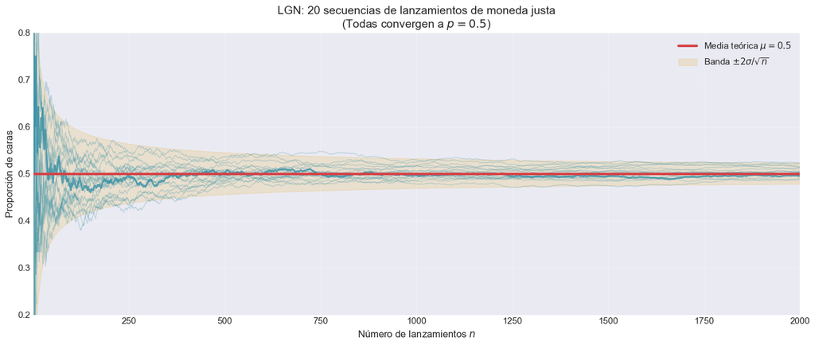

```python
# EJEMPLO 3: Múltiples trayectorias de convergencia

def multiples_trayectorias(n_trayectorias=20, n_max=2000, seed=42):
    """
    Muestra múltiples realizaciones de la convergencia de la media muestral.
    """
    rng_local = np.random.default_rng(seed)

    # Parámetros: Bernoulli(p=0.5) como lanzamiento de moneda
    p = 0.5
    mu_real = p

    fig, ax = plt.subplots(figsize=(14, 6))

    n_vals = np.arange(1, n_max + 1)

    # Generar múltiples trayectorias
    for i in range(n_trayectorias):
        X = rng_local.binomial(1, p, size=n_max)
        media_acum = np.cumsum(X) / n_vals
        alpha = 0.3 if i > 0 else 0.8
        lw = 0.8 if i > 0 else 2
        ax.plot(n_vals, media_acum, color=COLORS['accent'], alpha=alpha, linewidth=lw)

    # Media teórica y bandas
    ax.axhline(mu_real, color=COLORS['secondary'], linestyle='-', linewidth=3, label=f'Media teórica $\\mu = {mu_real}$')

    # Bandas de error estándar teóricas
    sigma = np.sqrt(p * (1-p))
    se_upper = mu_real + 2 * sigma / np.sqrt(n_vals)
    se_lower = mu_real - 2 * sigma / np.sqrt(n_vals)
    ax.fill_between(n_vals, se_lower, se_upper, color=COLORS['highlight'], alpha=0.2, label=r'Banda $\pm 2\sigma/\sqrt{n}$')

    ax.set_xlabel('Número de lanzamientos $n$')
    ax.set_ylabel('Proporción de caras')
    ax.set_title(f'LGN: {n_trayectorias} secuencias de lanzamientos de moneda justa\n(Todas convergen a $p = 0.5$)')
    ax.legend(loc='upper right')
    ax.set_xlim([1, n_max])
    ax.set_ylim([0.2, 0.8])
    ax.grid(True, alpha=0.3)

    plt.tight_layout()
    plt.show()

multiples_trayectorias()
```

# Parte II: Teorema del Límite Central (TLC)

## 3. Definición Formal

### 3.1 Enunciado del TLC

Sea $\{X_i\}_{i=1}^{n}$ una secuencia de variables aleatorias **i.i.d.** con:

$$\mathbb{E}[X_i] = \mu \quad \text{y} \quad \text{Var}(X_i) = \sigma^2 < \infty$$

Entonces, la **suma estandarizada** converge en distribución a una normal estándar:

$$Z_n = \frac{\sum_{i=1}^n X_i - n\mu}{\sigma\sqrt{n}} = \frac{\bar{X}_n - \mu}{\sigma/\sqrt{n}} \xrightarrow{d} \mathcal{N}(0, 1) \quad \text{cuando } n \to \infty$$

### 3.2 Forma equivalente

La distribución de la media muestral se aproxima a:

$$\bar{X}_n \stackrel{\text{aprox}}{\sim} \mathcal{N}\left(\mu, \frac{\sigma^2}{n}\right)$$

### 3.3 Interpretación profunda

> **"No importa la forma de la distribución original, la distribución de la media muestral se vuelve aproximadamente normal para $n$ suficientemente grande."**

Esto es extraordinario porque:

- La distribución original puede ser **muy asimétrica** (Exponencial)
- La distribución original puede ser **discreta** (Bernoulli, Poisson)
- La distribución original puede ser **bimodal** o **uniforme**

### 3.4 ¿Qué tan grande debe ser $n$?

Regla empírica:

- **Distribuciones simétricas:** $n \geq 20$ suele ser suficiente
- **Distribuciones moderadamente asimétricas:** $n \geq 30$
- **Distribuciones muy asimétricas:** $n \geq 50$ o más

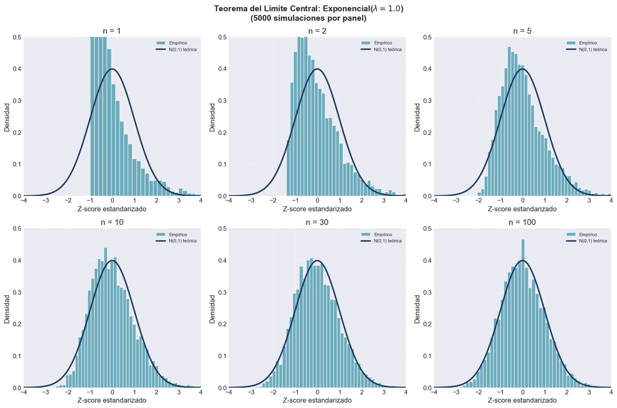

```python
# EJEMPLO 4: Demostración visual del TLC

def demostrar_tlc(distribucion='Exponencial', n_simulaciones=5000, seed=42):
    """
    Demuestra visualmente el Teorema del Límite Central.
    """
    rng_local = np.random.default_rng(seed)

    # Configurar distribución base
    if distribucion == 'Exponencial':
        lam = 1.0
        mu_real = 1/lam
        sigma_real = 1/lam
        generar = lambda size: rng_local.exponential(scale=1/lam, size=size)
        titulo_dist = f'Exponencial($\\lambda={lam}$)'
        color_hist = COLORS['accent']
    elif distribucion == 'Uniforme':
        a, b = 0, 1
        mu_real = (a + b) / 2
        sigma_real = (b - a) / np.sqrt(12)
        generar = lambda size: rng_local.uniform(a, b, size=size)
        titulo_dist = f'Uniforme({a}, {b})'
        color_hist = COLORS['success']
    elif distribucion == 'Bernoulli':
        p = 0.3
        mu_real = p
        sigma_real = np.sqrt(p * (1-p))
        generar = lambda size: rng_local.binomial(1, p, size=size)
        titulo_dist = f'Bernoulli(p={p})'
        color_hist = COLORS['secondary']
    else:  # Bimodal (mezcla de normales)
        def generar(size):
            u = rng_local.random(size=size)
            return np.where(u < 0.5, rng_local.normal(-3, 1, size), rng_local.normal(3, 1, size))
        mu_real = 0.5*(-3) + 0.5*(3)
        sigma_real = np.sqrt(10)  # aproximación
        titulo_dist = 'Bimodal (mezcla)'
        color_hist = COLORS['highlight']

    # Tamaños de muestra a visualizar
    ns = [1, 2, 5, 10, 30, 100]

    fig, axes = plt.subplots(2, 3, figsize=(15, 10))
    axes = axes.flatten()

    for idx, n in enumerate(ns):
        ax = axes[idx]

        # Generar muchas medias muestrales de tamaño n
        medias = np.array([np.mean(generar(n)) for _ in range(n_simulaciones)])

        # Estandarizar
        z_scores = (medias - mu_real) / (sigma_real / np.sqrt(n))

        # Histograma
        ax.hist(z_scores, bins=50, density=True, color=color_hist, alpha=0.7, edgecolor='white', label='Empírico')

        # Curva normal estándar teórica
        x_vals = np.linspace(-4, 4, 200)
        ax.plot(x_vals, stats.norm.pdf(x_vals), color=COLORS['primary'], linewidth=2.5, label='N(0,1) teórica')

        ax.set_xlim([-4, 4])
        ax.set_ylim([0, 0.5])
        ax.set_xlabel('Z-score estandarizado')
        ax.set_ylabel('Densidad')
        ax.set_title(f'n = {n}')
        ax.legend(loc='upper right', fontsize=8)
        ax.grid(True, alpha=0.3)

    fig.suptitle(f'Teorema del Límite Central: {titulo_dist}\n({n_simulaciones} simulaciones por panel)', fontsize=14, fontweight='bold')
    plt.tight_layout()
    plt.show()

# Demostrar con exponencial (muy asimétrica)
demostrar_tlc('Exponencial')
```

```python
# 🎛️ GRÁFICO INTERACTIVO: TLC con diferentes distribuciones

@interact(
    distribucion=Dropdown(
        options=['Exponencial', 'Uniforme', 'Bernoulli', 'Bimodal'],
        value='Exponencial',
        description='Distribución:'
    ),
    n_simulaciones=IntSlider(min=500, max=10000, step=500, value=3000, description='Simulaciones:')
)
def tlc_interactivo(distribucion, n_simulaciones):
    demostrar_tlc(distribucion, n_simulaciones)
```

```
interactive(children=(Dropdown(description='Distribución:', options=('Exponencial', 'Uniforme', 'Bernoulli', '…
```

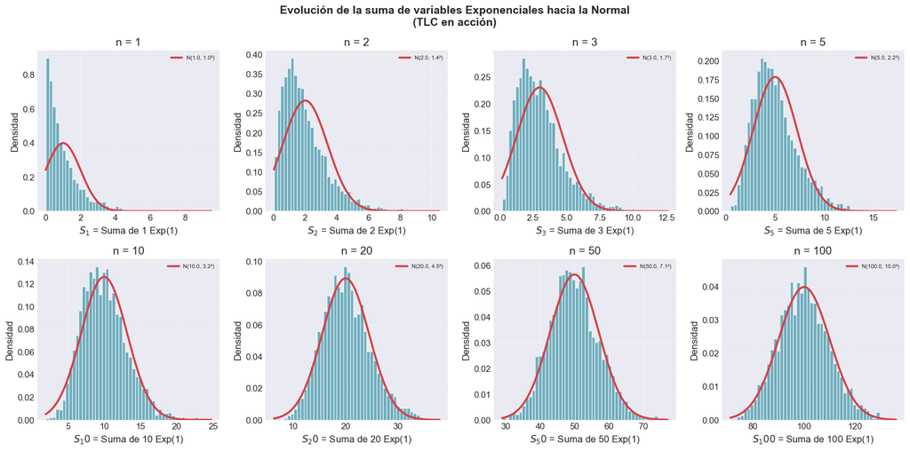

```python
# EJEMPLO 5: Evolución progresiva hacia la normalidad (suma de exponenciales)

def evolucion_tlc(n_simulaciones=3000, seed=42):
    """
    Muestra cómo la distribución evoluciona hacia la normal paso a paso.
    """
    rng_local = np.random.default_rng(seed)

    # Distribución muy asimétrica: Exponencial
    lam = 1.0
    mu_real = 1/lam
    sigma_real = 1/lam

    fig, axes = plt.subplots(2, 4, figsize=(16, 8))
    axes = axes.flatten()

    ns = [1, 2, 3, 5, 10, 20, 50, 100]

    for idx, n in enumerate(ns):
        ax = axes[idx]

        # Generar sumas (no medias) para ver la evolución
        sumas = np.array([np.sum(rng_local.exponential(scale=1/lam, size=n)) for _ in range(n_simulaciones)])

        # Histograma de las sumas
        ax.hist(sumas, bins=50, density=True, color=COLORS['accent'], alpha=0.7, edgecolor='white')

        # Ajustar curva normal teórica
        mu_suma = n * mu_real
        sigma_suma = sigma_real * np.sqrt(n)
        x_vals = np.linspace(sumas.min(), sumas.max(), 200)
        ax.plot(x_vals, stats.norm.pdf(x_vals, mu_suma, sigma_suma),
                color=COLORS['secondary'], linewidth=2.5, label=f'N({mu_suma:.1f}, {sigma_suma:.1f}²)')

        ax.set_xlabel(f'$S_{n}$ = Suma de {n} Exp(1)')
        ax.set_ylabel('Densidad')
        ax.set_title(f'n = {n}')
        ax.legend(loc='upper right', fontsize=7)
        ax.grid(True, alpha=0.3)

    fig.suptitle('Evolución de la suma de variables Exponenciales hacia la Normal\n(TLC en acción)', fontsize=14, fontweight='bold')
    plt.tight_layout()
    plt.show()

evolucion_tlc()
```

## 4. Aplicación: Intervalos de Confianza

### 4.1 Construcción del intervalo

Gracias al TLC, para $n$ grande:

$$\frac{\bar{X}_n - \mu}{s/\sqrt{n}} \stackrel{\text{aprox}}{\sim} \mathcal{N}(0, 1)$$

donde $s$ es la desviación estándar muestral.

Por lo tanto, un **intervalo de confianza del $(1-\alpha)\times 100\%$** para $\mu$ es:

$$\text{IC}_{1-\alpha} = \left[\bar{X}_n - z_{\alpha/2}\frac{s}{\sqrt{n}}, \quad \bar{X}_n + z_{\alpha/2}\frac{s}{\sqrt{n}}\right]$$

### 4.2 Valores críticos comunes

| Nivel de confianza | $\alpha$ | $z_{\alpha/2}$ |
| --- | --- | --- |
| 90% | 0.10 | 1.645 |
| 95% | 0.05 | 1.960 |
| 99% | 0.01 | 2.576 |

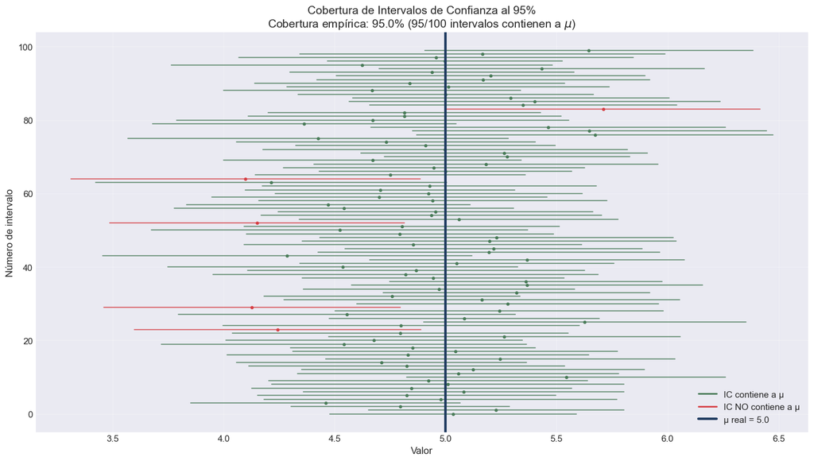

```
📊 Resumen:
   Nivel de confianza teórico: 95%
   Cobertura empírica: 95.0%
   Intervalos que cubren μ: 95 de 100
```

```python
# EJEMPLO 6: Cobertura de intervalos de confianza

def cobertura_ic(n=50, n_intervalos=100, confianza=0.95, seed=42):
    """
    Visualiza la cobertura empírica de intervalos de confianza.
    """
    rng_local = np.random.default_rng(seed)

    # Parámetros poblacionales
    mu_real = 5.0
    sigma_real = 2.0
    z_alpha = stats.norm.ppf(1 - (1-confianza)/2)

    fig, ax = plt.subplots(figsize=(14, 8))

    cubren = 0

    for i in range(n_intervalos):
        # Generar muestra
        X = rng_local.normal(mu_real, sigma_real, size=n)
        x_bar = np.mean(X)
        s = np.std(X, ddof=1)

        # Calcular IC
        margen = z_alpha * s / np.sqrt(n)
        ic_lower = x_bar - margen
        ic_upper = x_bar + margen

        # ¿Cubre el IC a μ?
        cubre = ic_lower <= mu_real <= ic_upper
        cubren += cubre

        color = COLORS['success'] if cubre else COLORS['secondary']
        ax.plot([ic_lower, ic_upper], [i, i], color=color, linewidth=1.5, alpha=0.7)
        ax.plot(x_bar, i, 'o', color=color, markersize=3)

    # Línea de la media real
    ax.axvline(mu_real, color=COLORS['primary'], linewidth=3, linestyle='-', label=f'$\\mu$ real = {mu_real}')

    cobertura_emp = cubren / n_intervalos

    ax.set_xlabel('Valor')
    ax.set_ylabel('Número de intervalo')
    ax.set_title(f'Cobertura de Intervalos de Confianza al {confianza*100:.0f}%\n'
                 f'Cobertura empírica: {cobertura_emp*100:.1f}% ({cubren}/{n_intervalos} intervalos contienen a $\\mu$)')

    # Leyenda personalizada
    from matplotlib.lines import Line2D
    legend_elements = [
        Line2D([0], [0], color=COLORS['success'], linewidth=2, label='IC contiene a μ'),
        Line2D([0], [0], color=COLORS['secondary'], linewidth=2, label='IC NO contiene a μ'),
        Line2D([0], [0], color=COLORS['primary'], linewidth=3, label=f'μ real = {mu_real}')
    ]
    ax.legend(handles=legend_elements, loc='lower right')
    ax.grid(True, alpha=0.3)

    plt.tight_layout()
    plt.show()

    print(f"\n📊 Resumen:")
    print(f"   Nivel de confianza teórico: {confianza*100:.0f}%")
    print(f"   Cobertura empírica: {cobertura_emp*100:.1f}%")
    print(f"   Intervalos que cubren μ: {cubren} de {n_intervalos}")

cobertura_ic(n=30, n_intervalos=100, confianza=0.95)
```

```python
# 🎛️ GRÁFICO INTERACTIVO: Cobertura de IC

@interact(
    n=IntSlider(min=10, max=200, step=10, value=50, description='Tamaño n:'),
    n_intervalos=IntSlider(min=20, max=200, step=10, value=100, description='# Intervalos:'),
    confianza=FloatSlider(min=0.80, max=0.99, step=0.01, value=0.95, description='Confianza:'),
    seed=IntSlider(min=1, max=100, value=42, description='Semilla:')
)
def ic_interactivo(n, n_intervalos, confianza, seed):
    cobertura_ic(n, n_intervalos, confianza, seed)
```

```
interactive(children=(IntSlider(value=50, description='Tamaño n:', max=200, min=10, step=10), IntSlider(value=…
```

# Parte III: Conexión entre LGN y TLC

## 5. Visión Unificada

### 5.1 Comparación

| Aspecto | Ley de los Grandes Números | Teorema del Límite Central |
| --- | --- | --- |
| **Pregunta** | ¿Hacia dónde converge $\bar{X}_n$? | ¿Cómo se distribuye $\bar{X}_n$? |
| **Respuesta** | Converge a $\mu$ | Se distribuye aprox. $N(\mu, \sigma^2/n)$ |
| **Tipo de convergencia** | Casi segura / En probabilidad | En distribución |
| **Información** | Punto de convergencia | Forma de la distribución |

### 5.2 Intuición geométrica

- **LGN:** La distribución de $\bar{X}_n$ se "concentra" cada vez más cerca de $\mu$.
- **TLC:** Esa concentración tiene forma de **campana** (normal).

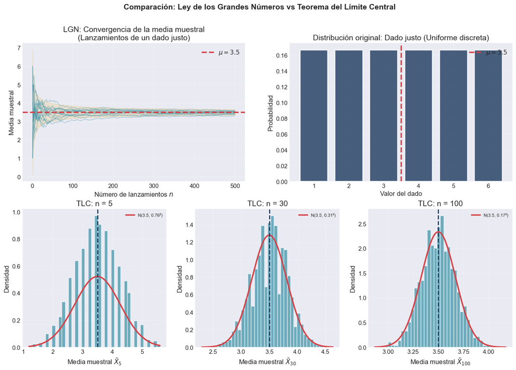

```python
# EJEMPLO 7: Visualización conjunta de LGN y TLC (lanzamiento de dados)

def lgn_vs_tlc(n_max=500, n_simulaciones=3000, seed=42):
    """
    Visualización lado a lado de LGN (convergencia) y TLC (distribución).
    """
    rng_local = np.random.default_rng(seed)

    # Distribución: Dados (Uniforme discreta 1-6)
    mu_real = 3.5
    sigma_real = np.sqrt(35/12)  # Varianza de dado justo

    fig = plt.figure(figsize=(16, 10))

    # Panel superior izquierdo: LGN - Convergencia de la media
    ax1 = fig.add_subplot(2, 2, 1)

    n_trayectorias = 15
    n_vals = np.arange(1, n_max + 1)

    for i in range(n_trayectorias):
        dados = rng_local.integers(1, 7, size=n_max)
        media_acum = np.cumsum(dados) / n_vals
        ax1.plot(n_vals, media_acum, alpha=0.4, linewidth=1, color=COLORS['accent'])

    ax1.axhline(mu_real, color=COLORS['secondary'], linewidth=2.5, linestyle='--', label=f'$\\mu = {mu_real}$')

    # Bandas de convergencia
    upper = mu_real + 2*sigma_real/np.sqrt(n_vals)
    lower = mu_real - 2*sigma_real/np.sqrt(n_vals)
    ax1.fill_between(n_vals, lower, upper, color=COLORS['highlight'], alpha=0.2)

    ax1.set_xlabel('Número de lanzamientos $n$')
    ax1.set_ylabel('Media muestral')
    ax1.set_title('LGN: Convergencia de la media muestral\n(Lanzamientos de un dado justo)')
    ax1.legend()
    ax1.grid(True, alpha=0.3)

    # Panel superior derecho: Distribución original
    ax2 = fig.add_subplot(2, 2, 2)
    valores = np.arange(1, 7)
    probs = np.ones(6) / 6
    ax2.bar(valores, probs, color=COLORS['primary'], alpha=0.8, edgecolor='white', linewidth=2)
    ax2.axvline(mu_real, color=COLORS['secondary'], linewidth=2.5, linestyle='--', label=f'$\\mu = {mu_real}$')
    ax2.set_xlabel('Valor del dado')
    ax2.set_ylabel('Probabilidad')
    ax2.set_title('Distribución original: Dado justo (Uniforme discreta)')
    ax2.set_xticks(valores)
    ax2.legend()
    ax2.grid(True, alpha=0.3)

    # Paneles inferiores: TLC - Distribución de la media para diferentes n
    ns_tlc = [5, 30, 100]

    for idx, n in enumerate(ns_tlc):
        ax = fig.add_subplot(2, 3, 4 + idx)

        # Simular muchas medias muestrales
        medias = np.array([np.mean(rng_local.integers(1, 7, size=n)) for _ in range(n_simulaciones)])

        # Histograma
        ax.hist(medias, bins=40, density=True, color=COLORS['accent'], alpha=0.7, edgecolor='white')

        # Curva normal teórica
        x_vals = np.linspace(medias.min(), medias.max(), 200)
        sigma_media = sigma_real / np.sqrt(n)
        ax.plot(x_vals, stats.norm.pdf(x_vals, mu_real, sigma_media),
                color=COLORS['secondary'], linewidth=2.5, label=f'N({mu_real}, {sigma_media:.2f}²)')

        ax.axvline(mu_real, color=COLORS['primary'], linewidth=2, linestyle='--')
        ax.set_xlabel(f'Media muestral $\\bar{{X}}_{{{n}}}$')
        ax.set_ylabel('Densidad')
        ax.set_title(f'TLC: n = {n}')
        ax.legend(fontsize=8)
        ax.grid(True, alpha=0.3)

    fig.suptitle('Comparación: Ley de los Grandes Números vs Teorema del Límite Central', fontsize=14, fontweight='bold')
    plt.tight_layout()
    plt.show()

lgn_vs_tlc()
```

# Parte IV: Aplicaciones Prácticas

## 6. Aplicación en Simulación Monte Carlo

### 6.1 Estimación de $\pi$ mediante simulación

Consideremos un cuadrado de lado 2 centrado en el origen, con un círculo inscrito de radio 1.

$$\frac{\text{Área del círculo}}{\text{Área del cuadrado}} = \frac{\pi \cdot 1^2}{2^2} = \frac{\pi}{4}$$

Si lanzamos puntos uniformemente en el cuadrado, la proporción que caen dentro del círculo estima $\pi/4$.

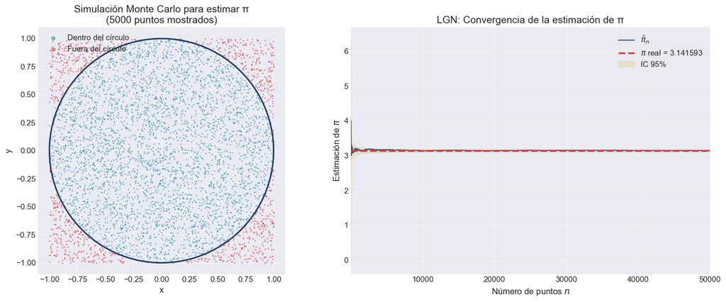

```
📐 Estimación de π:
   π estimado = 3.146320
   π real     = 3.141593
   Error      = 0.004727
   Error %    = 0.1505%
```

```python
# EJEMPLO 8: Estimación de π con Monte Carlo + LGN

def estimar_pi(n_puntos=10000, seed=42):
    """
    Estima π usando Monte Carlo y visualiza la convergencia (LGN).
    """
    rng_local = np.random.default_rng(seed)

    # Generar puntos uniformes en [-1, 1] x [-1, 1]
    x = rng_local.uniform(-1, 1, size=n_puntos)
    y = rng_local.uniform(-1, 1, size=n_puntos)

    # ¿Está dentro del círculo?
    dentro = (x**2 + y**2) <= 1

    # Estimación acumulada de π
    n_vals = np.arange(1, n_puntos + 1)
    pi_estimado = 4 * np.cumsum(dentro) / n_vals

    fig, axes = plt.subplots(1, 2, figsize=(15, 6))

    # Panel izquierdo: Visualización de puntos
    ax1 = axes[0]
    n_mostrar = min(5000, n_puntos)
    ax1.scatter(x[:n_mostrar][dentro[:n_mostrar]], y[:n_mostrar][dentro[:n_mostrar]],
                c=COLORS['accent'], s=1, alpha=0.5, label='Dentro del círculo')
    ax1.scatter(x[:n_mostrar][~dentro[:n_mostrar]], y[:n_mostrar][~dentro[:n_mostrar]],
                c=COLORS['secondary'], s=1, alpha=0.5, label='Fuera del círculo')

    # Dibujar círculo
    theta = np.linspace(0, 2*np.pi, 100)
    ax1.plot(np.cos(theta), np.sin(theta), color=COLORS['primary'], linewidth=2)

    ax1.set_xlim([-1.1, 1.1])
    ax1.set_ylim([-1.1, 1.1])
    ax1.set_aspect('equal')
    ax1.set_xlabel('x')
    ax1.set_ylabel('y')
    ax1.set_title(f'Simulación Monte Carlo para estimar π\n({n_mostrar} puntos mostrados)')
    ax1.legend(markerscale=5)
    ax1.grid(True, alpha=0.3)

    # Panel derecho: Convergencia de la estimación
    ax2 = axes[1]
    ax2.plot(n_vals, pi_estimado, color=COLORS['primary'], linewidth=1.5, alpha=0.8, label='$\\hat{\\pi}_n$')
    ax2.axhline(np.pi, color=COLORS['secondary'], linewidth=2.5, linestyle='--', label=f'$\\pi$ real = {np.pi:.6f}')

    # Bandas de IC al 95%
    p = np.pi/4
    se = 4 * np.sqrt(p*(1-p)) / np.sqrt(n_vals)
    ax2.fill_between(n_vals, np.pi - 1.96*se, np.pi + 1.96*se,
                     color=COLORS['highlight'], alpha=0.2, label='IC 95%')

    ax2.set_xlabel('Número de puntos $n$')
    ax2.set_ylabel('Estimación de $\\pi$')
    ax2.set_title('LGN: Convergencia de la estimación de π')
    ax2.legend()
    ax2.set_xlim([1, n_puntos])
    ax2.grid(True, alpha=0.3)

    plt.tight_layout()
    plt.show()

    # Resultados finales
    pi_final = pi_estimado[-1]
    error = abs(pi_final - np.pi)
    print(f"\n📐 Estimación de π:")
    print(f"   π estimado = {pi_final:.6f}")
    print(f"   π real     = {np.pi:.6f}")
    print(f"   Error      = {error:.6f}")
    print(f"   Error %    = {100*error/np.pi:.4f}%")

estimar_pi(n_puntos=50000)
```

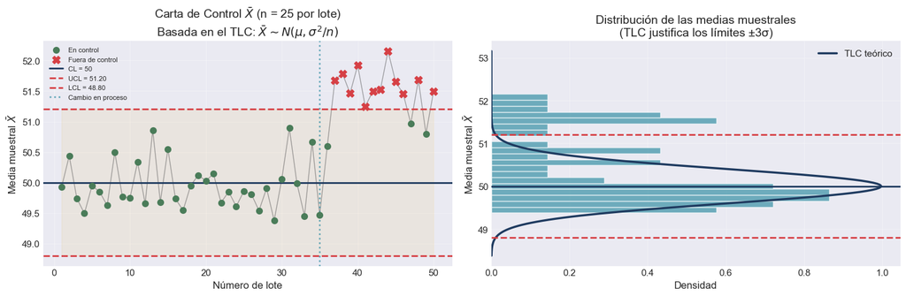

```
🏭 Resumen de Control de Calidad:
   Puntos fuera de control: 12 de 50
   Error estándar de X̄: σ/√n = 0.400
   UCL = μ + 3σ/√n = 51.200
   LCL = μ - 3σ/√n = 48.800
```

```python
# EJEMPLO 9: Aplicación en control de calidad (Cartas X-bar)

def control_calidad(mu_proceso=50, sigma_proceso=2, n_muestra=25, n_lotes=50, seed=42):
    """
    Simula una carta de control X-bar usando el TLC.
    """
    rng_local = np.random.default_rng(seed)

    # Límites de control (basados en TLC)
    sigma_xbar = sigma_proceso / np.sqrt(n_muestra)
    UCL = mu_proceso + 3 * sigma_xbar  # Límite superior
    LCL = mu_proceso - 3 * sigma_xbar  # Límite inferior

    fig, axes = plt.subplots(1, 2, figsize=(15, 5))

    # Simular n_lotes muestras
    medias = []
    for i in range(n_lotes):
        # Proceso normal para los primeros 35 lotes
        if i < 35:
            muestra = rng_local.normal(mu_proceso, sigma_proceso, size=n_muestra)
        else:
            # Cambio en el proceso (deriva)
            muestra = rng_local.normal(mu_proceso + 1.5, sigma_proceso, size=n_muestra)
        medias.append(np.mean(muestra))

    medias = np.array(medias)
    lotes = np.arange(1, n_lotes + 1)

    # Panel izquierdo: Carta X-bar
    ax1 = axes[0]

    # Puntos coloreados según control
    dentro_control = (medias >= LCL) & (medias <= UCL)
    ax1.scatter(lotes[dentro_control], medias[dentro_control],
                c=COLORS['success'], s=50, zorder=5, label='En control')
    ax1.scatter(lotes[~dentro_control], medias[~dentro_control],
                c=COLORS['secondary'], s=80, marker='X', zorder=5, label='Fuera de control')
    ax1.plot(lotes, medias, color=COLORS['neutral'], linewidth=1, alpha=0.5)

    # Límites de control
    ax1.axhline(mu_proceso, color=COLORS['primary'], linewidth=2, label=f'CL = {mu_proceso}')
    ax1.axhline(UCL, color=COLORS['secondary'], linewidth=2, linestyle='--', label=f'UCL = {UCL:.2f}')
    ax1.axhline(LCL, color=COLORS['secondary'], linewidth=2, linestyle='--', label=f'LCL = {LCL:.2f}')

    ax1.fill_between(lotes, LCL, UCL, color=COLORS['highlight'], alpha=0.1)
    ax1.axvline(35, color=COLORS['accent'], linewidth=2, linestyle=':', alpha=0.7, label='Cambio en proceso')

    ax1.set_xlabel('Número de lote')
    ax1.set_ylabel('Media muestral $\\bar{X}$')
    ax1.set_title(f'Carta de Control $\\bar{{X}}$ (n = {n_muestra} por lote)\nBasada en el TLC: $\\bar{{X}} \\sim N(\\mu, \\sigma^2/n)$')
    ax1.legend(loc='upper left', fontsize=8)
    ax1.grid(True, alpha=0.3)

    # Panel derecho: Distribución de las medias
    ax2 = axes[1]
    ax2.hist(medias, bins=20, density=True, orientation='horizontal',
             color=COLORS['accent'], alpha=0.7, edgecolor='white')

    # Distribución teórica (TLC)
    y_vals = np.linspace(medias.min() - 1, medias.max() + 1, 200)
    ax2.plot(stats.norm.pdf(y_vals, mu_proceso, sigma_xbar), y_vals,
             color=COLORS['primary'], linewidth=2.5, label='TLC teórico')

    ax2.axhline(UCL, color=COLORS['secondary'], linewidth=2, linestyle='--')
    ax2.axhline(LCL, color=COLORS['secondary'], linewidth=2, linestyle='--')
    ax2.axhline(mu_proceso, color=COLORS['primary'], linewidth=2)

    ax2.set_xlabel('Densidad')
    ax2.set_ylabel('Media muestral $\\bar{X}$')
    ax2.set_title('Distribución de las medias muestrales\n(TLC justifica los límites ±3σ)')
    ax2.legend()
    ax2.grid(True, alpha=0.3)

    plt.tight_layout()
    plt.show()

    n_fuera = np.sum(~dentro_control)
    print(f"\n🏭 Resumen de Control de Calidad:")
    print(f"   Puntos fuera de control: {n_fuera} de {n_lotes}")
    print(f"   Error estándar de X̄: σ/√n = {sigma_xbar:.3f}")
    print(f"   UCL = μ + 3σ/√n = {UCL:.3f}")
    print(f"   LCL = μ - 3σ/√n = {LCL:.3f}")

control_calidad()
```